# Polymath again (and differently)

### Patrick Allo

#### Oxford Internet Institute

## What is Polymath and why does it matter?

- (Massive) open collaborative mathematics project initiated by Tim Gowers in February 2009.
- Polymath 1 was devoted to the task of finding an elementary proof of the *Density Hales-Jewett Theorem*.
- Probable success was announced less than 6 weeks after the start of the project.
- Results were published under the name "D.H.J. Polymath".
- Still active: Polymath 10 and 11 started in the past few months.
- Several projects were successful and led to direct and indirect publications (some failed early).
- Small mini-projects based on questions from Math Olympiad final questions.

## For the philosophy of mathematical practice

- A large record of mathematical practice in action.
- A continuous reflection on the process by several participants, and especially by the more prominent participants (Gowers, Tao, Nielsen).
- A new type of mathematics and a new type of collaboration?
- A new example of ICT-mediated mathematics?
- Broader context: HoTT, theorem-provers and assistants, e-research, citizen science...

## For social epistemology

- Look at what actually happens instead of at a priori models of collaboration.
- Accessible to computational methods.
- Opportunity to mix theoretical insights with empirical study.

## Why again?

- A lot has already been written by Timothy Gowers (Gowers & Nielsen. 2009. Massively collaborative mathematics. *Nature* 46.) himself, and by Michael Nielsen in "Reinventing discovery : the new era of networked science".
- Polymath attracted a lot of attention, even in more popular venues like New Scientist.
- Quantitative and social network analysis of Polymath 1 by Cranshaw & Kittur (2011).
- Studied within the "Social Machine of Mathematics" project by Pease and Martin.
- More publications by: Varshney (2012), Stefaneas & Vandoulakis (2012).
- Van Bendegem, J.P., 2014, Logic, Methodology and Philosophy of Science. Proceedings of the 14th International Congress (Nancy). Logic and Science Facing the New Technologies, Mathematics and the new technologies, part III: The cloud and the web of proofs. College Publications, London, pp. 427-39.
- Allo, P., Bendegem, J.P.V. & Kerkhove, B.V. 2013, Mathematical Arguments and Distributed Knowledge, in Abderdein & Dove (eds), The Argument of Mathematics, Springer Netherlands, Dordrecht, pp. 339-60.

## More and better!

- Still active and growing...
  - Polymath 10 on the "Erdos-Rado Sunflower problem" (Gil Kalai) started in November 2015.
  - Polymath 11 on "Frankl’s union-closed conjecture" (Gowers) officially started a few weeks ago.
- Better theoretical insight in e-science, but also for the study of research-communities.
- Situate Polymath within the broader context of e-research and citizen science (an outlier in both fields).
- Empirical study informed by better theoretical models. (Not simply *retelling the story*)

## Tools and methods

- Synergy between the philosophy of mathematical practice, social epistemology and the study of scientific communities, and sociology of e-research.
- Complementing computational social science with insights and concepts from formal models of interaction.
- Two-way interaction between data-driven analysis and formal modelling:
  1. Use insight in the data to develop formal models.
  2. Use insight from formal models as a typology of valuable patterns of interaction.

### The details

- Web-scraping with `BeautifullSoup`.
- Network analysis with `networkx`.
- `Pandas` for its convenient `DataFrame` and `Series` data-structures.
- `Matplotlib` and `Seaborn` for visualisation.

Information from the discussion-threads is stored in two types of directed-graphs:

- Discussion-threads, with comments as nodes and child-parent links as directed edges.
- Author-networks (or interaction networks), with authors as nodes and weighted directed edges as interactions.
- Polymath-style blog-mathematics became possible because of the availability of a LaTeX-plugin for WordPress, but precisely the LaTeX-content is a blind-spot in this inquiry.
- Agent-based modelling and communities as graphs (Zollman).
- Insights from logics for multi-agent systems:
  - Dynamic epistemic logic.
  - Logics for teamwork (Dunin-Keplicz & Verbrugge).

## The Polymath Projects

- **Polymath1:** New proofs and bounds for the density Hales-Jewett theorem. Initiated Feb 1, 2009; research results have now been published.
- **Polymath2:** Must an “explicitly defined” Banach space contain $c_0$ or $l_p$? Initiated Feb 17, 2009; attempts to relaunch via wiki, June 9 2010.
- **Polymath3:** The polynomial Hirsch conjecture. Proposed July 17, 2009; launched, September 30, 2010.
- **Polymath4:** A deterministic way to find primes. Proposed July 27, 2009; launched Aug 9, 2009. Research results have now been published.
- **Polymath5:** The Erdős discrepancy problem. Proposed Jan 10, 2010; launched Jan 19, 2010. Activity ceased by the end of 2012, but results from the project were used to solve the problem in 2015.
- **Polymath6:** Improving the bounds for Roth's theorem. Proposed Feb 5, 2011. Partial result published by non-participant
- **Polymath7:** Establishing the Hot Spots conjecture for acute-angled triangles. Proposed, May 31st, 2012; launched, Jun 8, 2012.
- **Polymath8:** Improving the bounds for small gaps between primes. Proposed, June 4, 2013; launched, June 4, 2013. Research results have now been published.
- **Polymath9:** exploring Borel determinacy-based methods for giving complexity bounds. Proposed, Oct 24, 2013; launched, Nov 3, 2013.
- **Polymath10:** improving the bounds for the Erdos-Rado sunflower lemma. Launched, Nov 2, 2015. ongoing
- **Polymath11:** proving Frankl's union-closed conjecture. Proposed Jan 21, 2016; launched Jan 29, 2016. ongoing

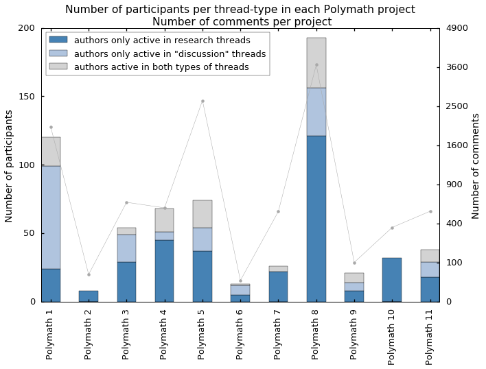

```python
from matplotlib.ticker import FuncFormatter

PROJECTS_TO_C = ["Polymath {}".format(i) for i in range(1, len(POLYMATHS)+1)]
PARTICIPANTS = Series([PM_FRAME.loc[project]['authors (accumulated)'].iloc[-1] for
                project in PROJECTS_TO_C], index=PROJECTS_TO_C)
R_NETWORKS = Series([PM_FRAME.loc[project]['r_network'].dropna().iloc[-1] for project in PROJECTS_TO_C],
                    index=PROJECTS_TO_C)
WITH_D = [project for project in PROJECTS_TO_C if not PM_FRAME.loc[project]['research'].all()]
D_NETWORKS = Series([PM_FRAME.loc[project]['d_network'].dropna().iloc[-1] for project in WITH_D],
                    index=WITH_D)
R_PARTICIPANTS = R_NETWORKS.apply(lambda network: set(network.author_frame.index))
D_PARTICIPANTS = D_NETWORKS.apply(lambda network: set(network.author_frame.index))
COMMENTS = Series([PM_FRAME.loc[project]['number of comments (accumulated)'].iloc[-1] for
                project in PROJECTS_TO_C], index=PROJECTS_TO_C)

df = DataFrame({'all threads': PARTICIPANTS, 'research threads': R_PARTICIPANTS, 'discussion threads': D_PARTICIPANTS},
              index=PROJECTS_TO_C)
df['authors only active in research threads'] = df['research threads'] - df['discussion threads']
df['authors only active in "discussion" threads'] = df['discussion threads'] - df['research threads']
df['authors active in both types of threads'] = df['all threads'] - df['authors only active in research threads'] - df['authors only active in "discussion" threads']
for project in PROJECTS_TO_C:
    if pd.isnull(df.loc[project]['authors only active in research threads']):
        df.loc[project]['authors only active in research threads'] = df.loc[project]['all threads']
data = df[['authors only active in research threads', 'authors only active in "discussion" threads', 'authors active in both types of threads']]
data = data.applymap(lambda set: len(set) if pd.notnull(set) else 0)
matplotlib.style.use(SBSTYLE)
axes = data.plot(kind='bar', stacked=True, color=['steelblue', 'lightsteelblue', 'lightgrey'],
          title="Number of participants per thread-type in each Polymath project\n Number of comments per project")
axes.set_ylabel("Number of participants")
data2 = np.sqrt(COMMENTS)
axes2 = axes.twinx()
axes2.yaxis.set_major_formatter(FuncFormatter(lambda x, pos:"{:0.0f}".format(np.square(x))))
axes2.set_ylabel("Number of comments")
axes2.plot(axes.get_xticks(), data2.values,
                   linestyle='-', marker='.', linewidth=.5,
                   color='darkgrey')
```

### Comparing the growth of successful and unsuccessful projects

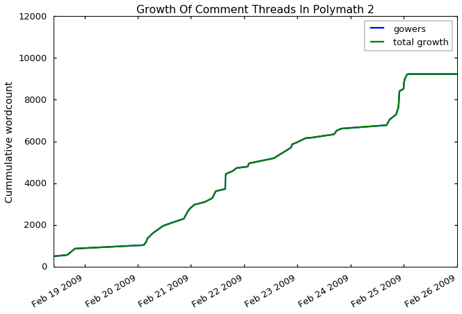

```python
plot_growth("Polymath 2", last='2009-02-26')
```

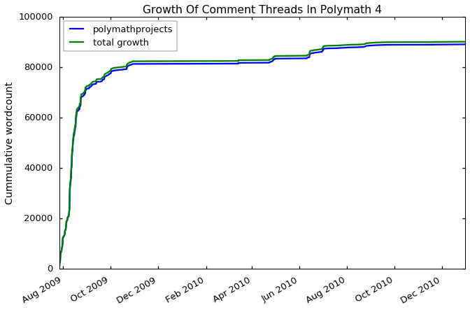

```python
plot_growth("Polymath 4", last='2010-12-31')
```

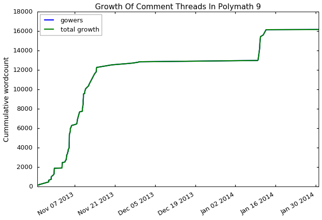

```python
plot_growth("Polymath 9", last='2014-01-31')
```

## Evolution of the Community

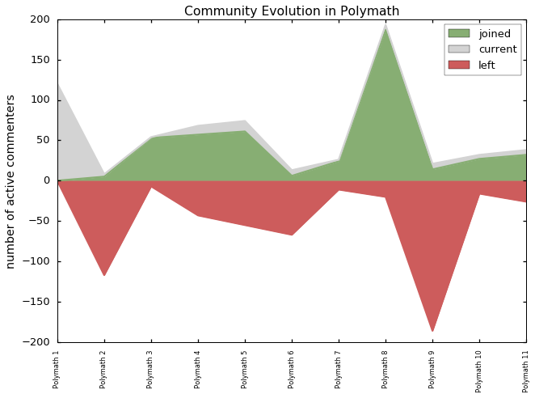

```python
plot_community_evolution("Polymath")
```

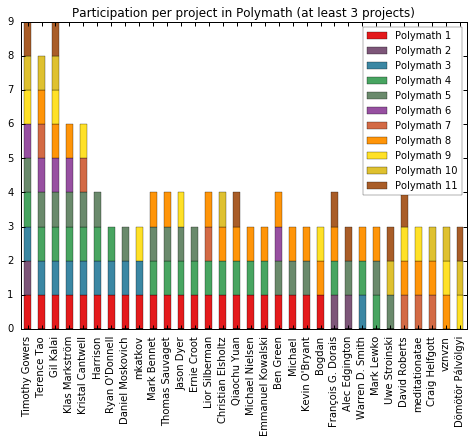

```python
plot_participation_evolution("Polymath", n=3)
```

Small constant user-based that was established during the early stages.

## Polymath 1: Overview

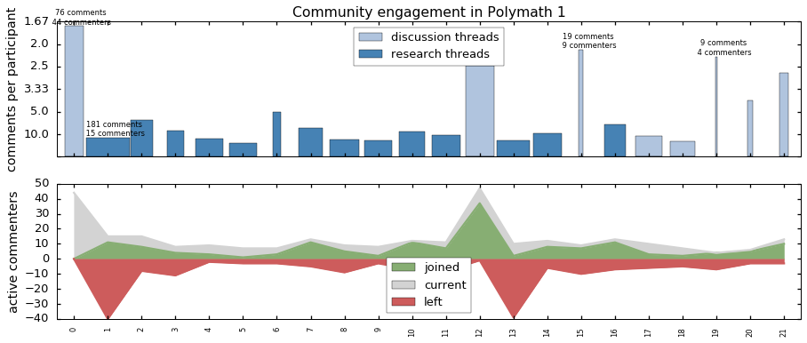

```python
plot_thread_evolution("Polymath 1", compress=140, sel=[0, 1, 15, 19], sharex=True)
```

- Highly diverse discussion-threads, but less diverse research-threads
- Polymath 1 included parallel discussions, which may partially cause the variation in engagement.

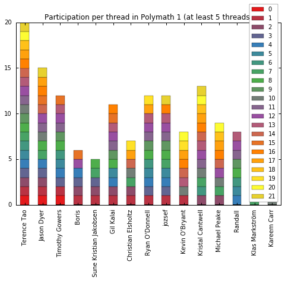

```python
plot_participation_evolution("Polymath 1", n=5)
```

- Only for "early adopters" (remains true if we reduce the lower-bound).
- High cost for late-commers is a recurring theme in the literature.
- Does not show how much was contributed to each thread.

## Polymath 1: Roles and activity

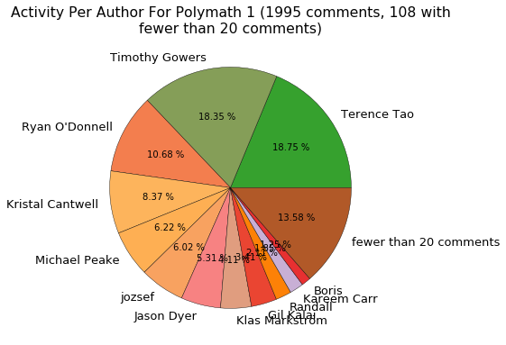

```python
plot_activity_pie("Polymath 1")
```

Only 4 participants are responsible for over 50% of all comments.

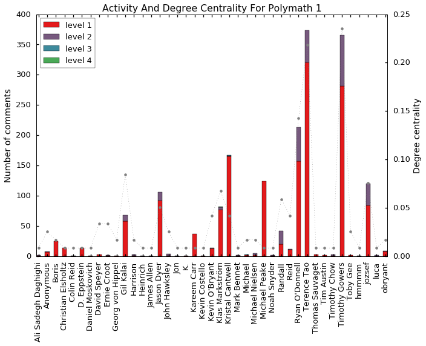

```python
plot_activity_degree("Polymath 1")
```

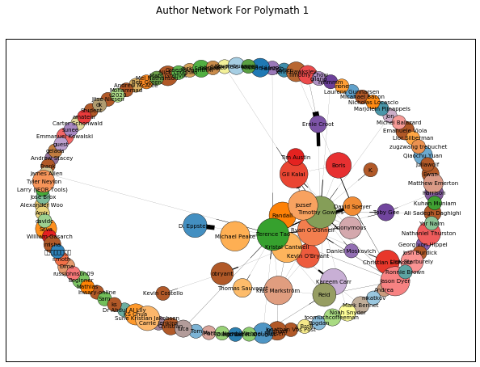

```python
draw_network("Polymath 1")
```

Small "core" with large periphery.

## Polymath 1: A Closer Look

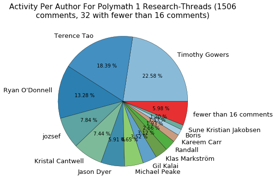

```python
PM1_R.plot_author_activity_pie(project="Polymath 1 research-threads")
```

- Commenting-activity is even more concentrated if we only look at research-threads.
- But there are also fewer commenters who contributed only a little (less than 1% of the total number of comments).

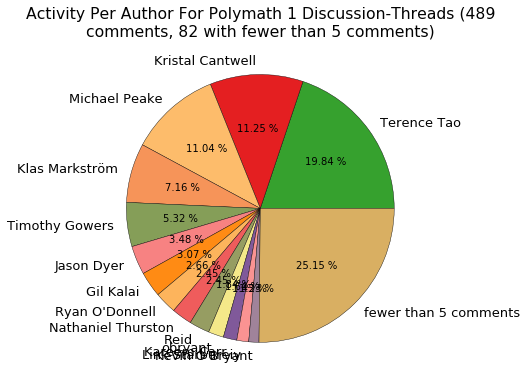

```python
PM1_D.plot_author_activity_pie(project="Polymath 1 discussion-threads")
```

- 50% is still contributed by a small group.
- But 1 in 4 commenters contributed at most 1% of the total number of comments.

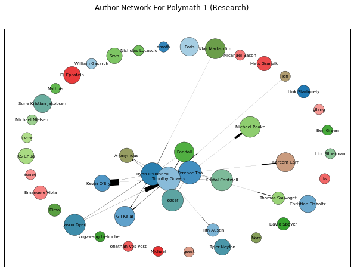

```python
PM1_R.draw_graph(project="Polymath 1 (research)")
```

- The periphery is much smaller if we only take the research-threads into account.
- The "lack of connectivity" is an artefact of Polymath 1, where nested comments only became available at a later stage.

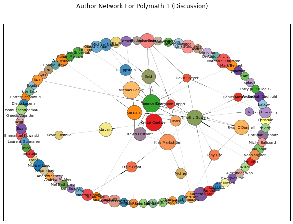

```python
PM1_D.draw_graph(project="Polymath 1 (discussion)")
```

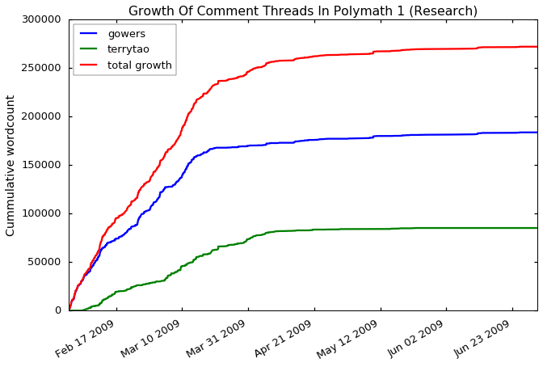

```python
get_project_at("Polymath 1", 16)['r_mthread (accumulated)'].plot_growth(project="Polymath 1 (research)", last="2009-07-01")
```

Steady growth in the research-threads.

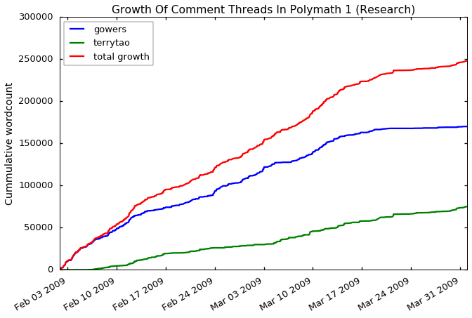

```python
get_project_at("Polymath 1", 16)['r_mthread (accumulated)'].plot_growth(project="Polymath 1 (research)", last="2009-04-01")
```

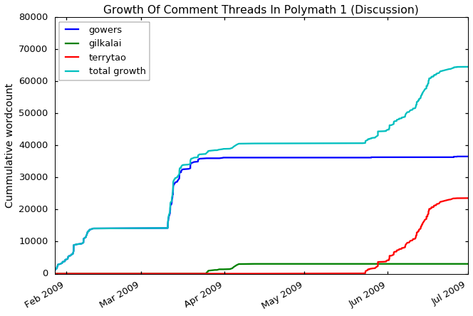

```python
get_project_at("Polymath 1", -1)['d_mthread (accumulated)'].plot_growth(project="Polymath 1 (discussion)", last="2009-07-01")
```

Intense, but short discussion-threads between the research-threads.

- Lower volume.
- The two steep parts are threads 0 and thread 12.

## The parallel development in Polymath 1

- The discussion on Tao's blog happened in parrallel of the main discussion on Gowers' blog.
- The question targetted on Tao's blog was different from the one on which Gowers focused.

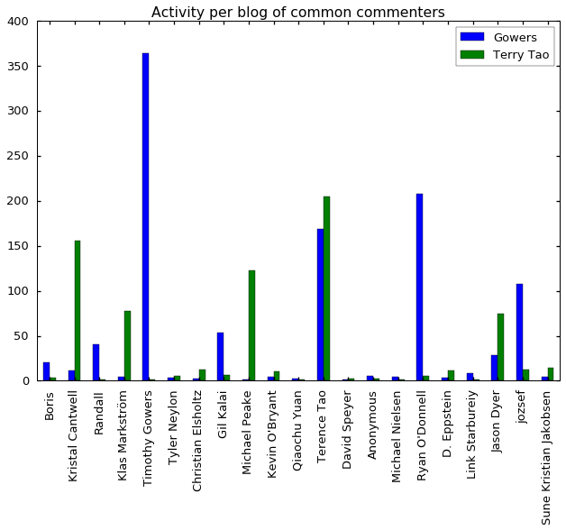

```python
GOWERS = PM_1['gow_network'].dropna().iloc[-1].author_frame
TAO = PM_1['tao_network'].dropna().iloc[-1].author_frame

common = list(set(GOWERS.index).intersection(set(TAO.index)))
common_frame = DataFrame({'Gowers': GOWERS['total comments'][common],
                          'Terry Tao' : TAO['total comments'][common]})

matplotlib.style.use(SBSTYLE)
common_frame.plot(kind="bar", title="Activity per blog of common commenters")
```

- As shown, Tao can be seen as the main *bridge* between both discussions.
- If we focus on the network based on the research-threads, both Tao, O'Donnel and Gowers are *articulation-points*.

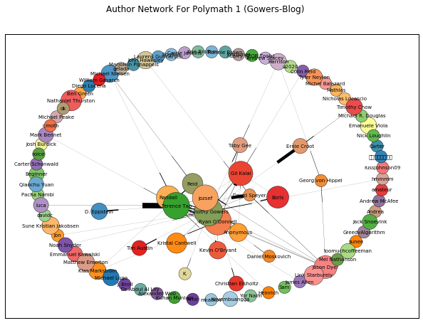

```python
PM_1['gow_network'].dropna().iloc[-1].draw_graph(project="Polymath 1 (Gowers-blog)")
```

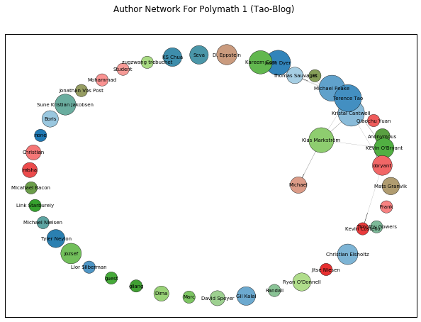

```python
PM_1['tao_network'].dropna().iloc[-1].draw_graph(project="Polymath 1 (Tao-blog)")
```

## Polymath 4 as a point of comparison

- Smaller, but successful project.
- Fewer discussion-threads.
- Everything happens on a single blog.
- Genuinely nested discussion.

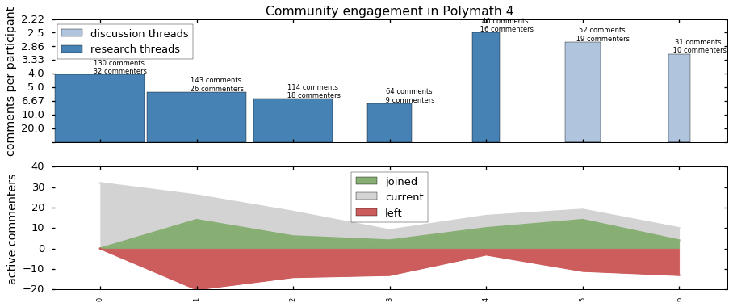

```python
plot_thread_evolution("Polymath 4", compress=140, sel=[0, 1, 2, 3, 4, 5, 6], sharex=True)
```

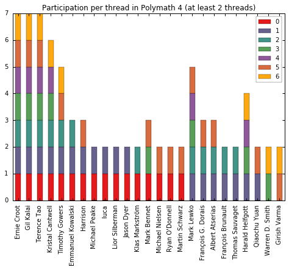

```python
plot_participation_evolution("Polymath 4", n=2)
```

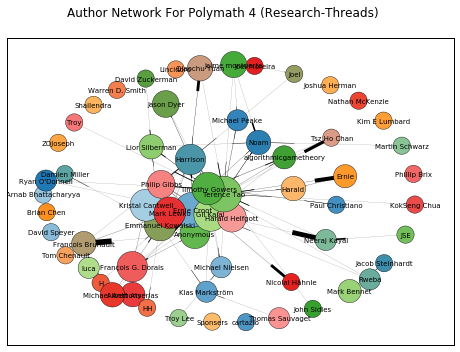

```python
PM_FRAME.loc['Polymath 4']['r_network'].dropna().iloc[-1].draw_graph(project="Polymath 4 (research-threads)")
```

- A single large weakly connected component of 47 participats.
- A single large strongly connected component of 31 participants.
- One weakly/strongly connected component of 2 participants (Mark Bennet, Jacob Steinhardt)
- 13 not weakly connected participants.
- 19 not strongly connected participants.
- 12 articulation points (in undirected graph); not necessarily the most active participants.

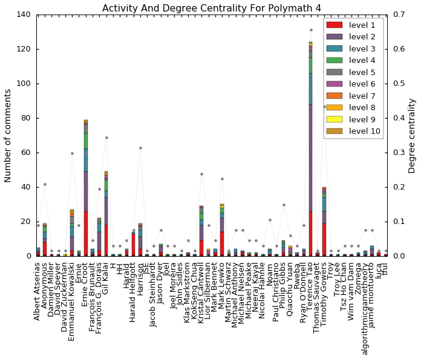

```python
plot_activity_degree("Polymath 4")
```

## The structure of communication in scientific communities

#### What is the optimal structure of communication (given certain assumptions) for a given epistemic aim?

- Bala & Goyal model adapted by Zollman.
- Communities are represented as graphs.
- Individual agents are Bayesian learners.
- Success = converging to the truth.
- Main insight: maximal connectivity is *not* the optimal organisation (being shielded from potentially bad information is beneficial).

#### The associated typology of communities is graph-based

- Two communities are different if their associated graphs are not isomorphic.
- Because connections are "available channels", Polymath seems to lead to maximal connectivity (all information is public).
- This is not optimal, but it is also not reflected in the actual communication-patterns.
- Further obstacles:
  - more complex problem (not merely choosing between alternatives).
  - epistemic cost for latecommers limits the potential benefit of maximal connectivity.
  - interactions are replies instead of *mere observations*.
  - information about *who reads what* is not directly available.

## Announcement-types as an alternative typology?

#### Why?

- "Mere access" does not explain why and how Polymath works.
- We only know who's "talking," but not who's listening.
- We're interested in collaboration, and not just in information-flow (collaborative problem-solving is not just judgement aggregation).
- Finer typology of group-structure by looking at patterns of one-to-many communication.

#### Proposal: focus on the role of group-attitudes

- Typical attitudes associated with *teamwork* are:
  - Mutual intentions
  - Common intentions
  - Group commitments
- Insights from "Logics from teamwork":

$\mathsf{M\text{-}INT}_G \phi \leftrightarrow \mathsf{E\text{-}INT}_G (\phi \wedge \mathsf{M\text{-}INT}_G \phi)$

$\mathsf{C\text{-}INT}_G \phi \leftrightarrow \mathsf{M\text{-}INT}_G \phi \wedge \mathsf{Aw}_G (\mathsf{M\text{-}INT}_G \phi)$

$\mathsf{COMM}(i, j, \phi) \to \mathsf{C\text{-}BEL}_{\{i, j\}} \mathsf{COMM}(i, j, \phi)$

- This underscores the importance of higher-order attitudes for successful collaboration.
- But common-attitudes are special in the sense that they can only be achieved through *public announcements*.

## Asynchronic communication versus the needs and apparence of public communication

#### What we expect

- Leading figures can *set the agenda*.
- Setting the agenda means creating common goals.
- Common goals require common attitudes, and hence public announcements.

#### What can be expected

- Blog-communication is asynchronous communication.
- Common attitudes are out of reach.

#### But there is hope

- Perhaps something weaker is sufficient (Dunin-Keplicz & Verbrugge explicitly consider this).
- The actual success of Polymath suggests that blog-interaction can be used for team-work (but there is also an explicit record of why it is difficult).
- At least the blog-posts (as opposed to the comments) should qualify as public announcements.

#### A proposal

- The success of Polymath does not just result from how central figures create a common ground from a diverse input.
- The crucial aspect is that central figures are powerful aggregators...
- ... that can always be reached by the participants.
- Not only can central figures reliably reach a large subset of the participants (one-to-many), the participants can also relaibly reach the central figures (one-to-one).
- Even more: all participants can with a high probability reach those who have recently been active (supported by high speed of interaction).
- Hence, even if the cost of contributing may be high, there is a guarantee of being heard (by the most powerful, best informed, ...).

## The "centre of discussion" metaphor

- If *A* just contributed, *A* is at the centre of discussion.
- How far *A* is from the centre of discussion depends on the time ellapsed since the last intervention.
- The probability of being heard by *A* depends on how far *A* is from the centre.
- This creates a basis of localised, probable public announcements.
- But it is also something we can actually investigate.

## Centre of discussion visualised

[figure not shown]

## Conclusion

- We can mix formal and data-driven investigation.
- Polymath is a valuable, but also an unusual case of e-research (ask me if you want to know more).
- There should be opportunities to introduce formal insights into computational social science that looks at how information flows in communities.